# Proposal

### Dự đoán tổng chi tiêu của khách hàng dựa trên thu nhập cá nhân, số lần mua hàng theo các phương thức,…

```r
colSums(is.na(marketing_data))
```

```
##           Education              Income         Dt_Customer             Recency
##                   0                   0                   0                   0
##            MntWines           MntFruits     MntMeatProducts     MntFishProducts
##                   0                   0                   0                   0
##    MntSweetProducts        MntGoldProds   NumDealsPurchases     NumWebPurchases
##                   0                   0                   0                   0
## NumCatalogPurchases   NumStorePurchases   NumWebVisitsMonth        AcceptedCmp3
##                   0                   0                   0                   0
##        AcceptedCmp4        AcceptedCmp5        AcceptedCmp1        AcceptedCmp2
##                   0                   0                   0                   0
##            Response            Complain             Country          Rel_Status
##                   0                   0                   0                   0
##            MntSpent        NumPurchases            TotalKid       TotalAccepted
##                   0                   0                   0                   0
##               Child
##                   0
```

```r
data_1<- na.omit(marketing_data)
str(data_1)
```

```
## 'data.frame':    1584 obs. of  29 variables:
##  $ Education          : chr  "Graduation" "Graduation" "Graduation" "Graduation" ...
##  $ Income             : int  57091 67267 32474 21474 63564 44931 65324 65324 62499 26872 ...
##  $ Dt_Customer        : chr  "6/15/2014" "5/13/2014" "11/5/2014" "8/4/2014" ...
##  $ Recency            : int  0 0 0 0 0 0 0 0 0 0 ...
##  $ MntWines           : int  464 134 10 6 769 78 384 384 140 3 ...
##  $ MntFruits          : int  5 11 0 16 80 0 0 0 4 10 ...
##  $ MntMeatProducts    : int  64 59 1 24 252 11 102 102 61 8 ...
##  $ MntFishProducts    : int  7 15 0 11 15 0 21 21 0 3 ...
##  $ MntSweetProducts   : int  0 2 0 0 34 0 32 32 13 16 ...
##  $ MntGoldProds       : int  37 30 0 34 65 7 5 5 4 32 ...
##  $ NumDealsPurchases  : int  1 1 1 2 1 1 3 3 2 1 ...
##  $ NumWebPurchases    : int  7 3 1 3 10 2 6 6 3 1 ...
##  $ NumCatalogPurchases: int  3 2 0 1 10 1 2 2 1 1 ...
##  $ NumStorePurchases  : int  7 5 2 2 7 3 9 9 6 2 ...
```

[output cut: 17 more lines]

- Chia mô hình thành 2 tập (70% train, 30% test)

```r
set.seed(123)
sample <- sample.split(marketing_data , SplitRatio = 0.7)
X_train <- subset(marketing_data, sample == TRUE)
X_test <- subset(marketing_data, sample == FALSE)
```

- Huấn luyện mô hình

```r
model <- lm(X_train$MntSpent ~ .- Dt_Customer - MntGoldProds - MntSweetProducts - MntFishProducts - MntMeatProducts - MntWines - MntFruits, data = X_train)

summary(model)
```

```
##
## Call:
## lm(formula = X_train$MntSpent ~ . - Dt_Customer - MntGoldProds -
##     MntSweetProducts - MntFishProducts - MntMeatProducts - MntWines -
##     MntFruits, data = X_train)
##
## Residuals:
##     Min      1Q  Median      3Q     Max
## -813.41  -65.98  -13.56   42.65  888.76
##
## Coefficients: (2 not defined because of singularities)
##                       Estimate Std. Error t value Pr(>|t|)
## (Intercept)         -3.712e+02  3.589e+01 -10.343  < 2e-16 ***
## EducationBasic       6.266e+01  2.792e+01   2.244 0.025017 *
## EducationGraduation  1.361e+00  1.615e+01   0.084 0.932874
## EducationMaster     -7.191e+00  1.804e+01  -0.399 0.690210
## EducationPhD         1.136e+01  1.791e+01   0.634 0.526206
## Income               6.153e-03  4.871e-04  12.632  < 2e-16 ***
## Recency             -9.946e-03  1.546e-01  -0.064 0.948721
## NumDealsPurchases    2.337e+00  3.016e+00   0.775 0.438661
## NumWebPurchases      2.200e+01  2.736e+00   8.042 2.35e-15 ***
## NumCatalogPurchases  7.746e+01  3.451e+00  22.447  < 2e-16 ***
## NumStorePurchases    3.571e+01  2.608e+00  13.694  < 2e-16 ***
## NumWebVisitsMonth    2.220e+01  2.806e+00   7.910 6.41e-15 ***
## AcceptedCmp3         1.146e+01  1.902e+01   0.602 0.546981
## AcceptedCmp4         3.985e+01  1.975e+01   2.018 0.043830 *
## AcceptedCmp5         2.128e+02  3.290e+01   6.467 1.52e-10 ***
## AcceptedCmp1         1.375e+02  3.245e+01   4.238 2.45e-05 ***
## AcceptedCmp2         5.118e+01  5.612e+01   0.912 0.362000
## Response             1.583e+01  1.613e+01   0.982 0.326520
## Complain            -7.684e+00  4.004e+01  -0.192 0.847869
## CountryCA           -1.657e+01  2.096e+01  -0.791 0.429411
## CountryGER          -1.998e+01  2.524e+01  -0.792 0.428746
## CountryIND          -5.878e+00  2.306e+01  -0.255 0.798848
## CountrySA           -7.337e+00  2.025e+01  -0.362 0.717223
## CountrySP           -5.060e+00  1.796e+01  -0.282 0.778266
## CountryUS           -5.238e+01  2.722e+01  -1.924 0.054605 .
## Rel_StatusSingle    -3.013e+00  9.174e+00  -0.328 0.742630
## NumPurchases                NA         NA      NA       NA
## TotalKid            -2.508e+01  9.875e+00  -2.539 0.011248 *
## TotalAccepted               NA         NA      NA       NA
## Child               -5.856e+01  1.755e+01  -3.338 0.000874 ***
## ---
## Signif. codes:  0 '***' 0.001 '**' 0.01 '*' 0.05 '.' 0.1 ' ' 1
##
## Residual standard error: 142.5 on 1064 degrees of freedom
## Multiple R-squared:  0.8701, Adjusted R-squared:  0.8668
## F-statistic:   264 on 27 and 1064 DF,  p-value: < 2.2e-16
```

- Các biến ảnh hưởng đến mô hình

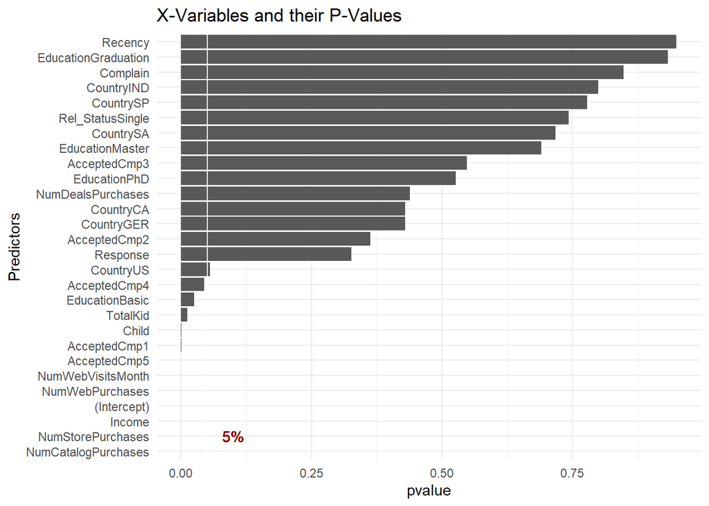

```r
pvaluedf <- data.frame(summary(model)$coefficients[,c('Pr(>|t|)', 'Estimate')])
colnames(pvaluedf) <- c('pvalue', 'coefficient')
pvaluedf$variables <- rownames(pvaluedf)

#Plot the variables and their significance
pvaluedf %>%
  ggplot(aes(x = reorder(variables, pvalue),y = pvalue)) +
    geom_col() +
    geom_hline(yintercept = 0.05, color = "white") + ## level of Significance
    geom_text(aes(x = 2, y = 0.10),label = "5%", color = "darkred") +
    scale_x_discrete(name = "Predictors") +
    ggtitle("X-Variables and their P-Values") +
    coord_flip() +
    theme_minimal()
```

- Huấn luyện mô hình sau khi tìm được các giá trị có ảnh hưởng

```r
re_select <-select( X_train ,c('Income', 'MntSpent', 'NumWebVisitsMonth', 'NumCatalogPurchases', 'NumWebPurchases', 'NumStorePurchases'))
model1 <- lm(X_train$MntSpent ~., data = re_select)

summary(model1)
```

```
##
## Call:
## lm(formula = X_train$MntSpent ~ ., data = re_select)
##
## Residuals:
##     Min      1Q  Median      3Q     Max
## -739.94  -81.91  -18.30   41.63 1006.59
##
## Coefficients:
##                       Estimate Std. Error t value Pr(>|t|)
## (Intercept)         -4.466e+02  2.840e+01 -15.725  < 2e-16 ***
## Income               6.157e-03  4.665e-04  13.198  < 2e-16 ***
## NumWebVisitsMonth    2.034e+01  2.847e+00   7.145 1.65e-12 ***
## NumCatalogPurchases  9.006e+01  3.500e+00  25.729  < 2e-16 ***
## NumWebPurchases      2.049e+01  2.806e+00   7.303 5.42e-13 ***
## NumStorePurchases    3.701e+01  2.662e+00  13.902  < 2e-16 ***
## ---
## Signif. codes:  0 '***' 0.001 '**' 0.01 '*' 0.05 '.' 0.1 ' ' 1
##
## Residual standard error: 155 on 1086 degrees of freedom
## Multiple R-squared:  0.8432, Adjusted R-squared:  0.8425
## F-statistic:  1168 on 5 and 1086 DF,  p-value: < 2.2e-16
```

- Biểu đồ thể hiện sư phân tán của sai số

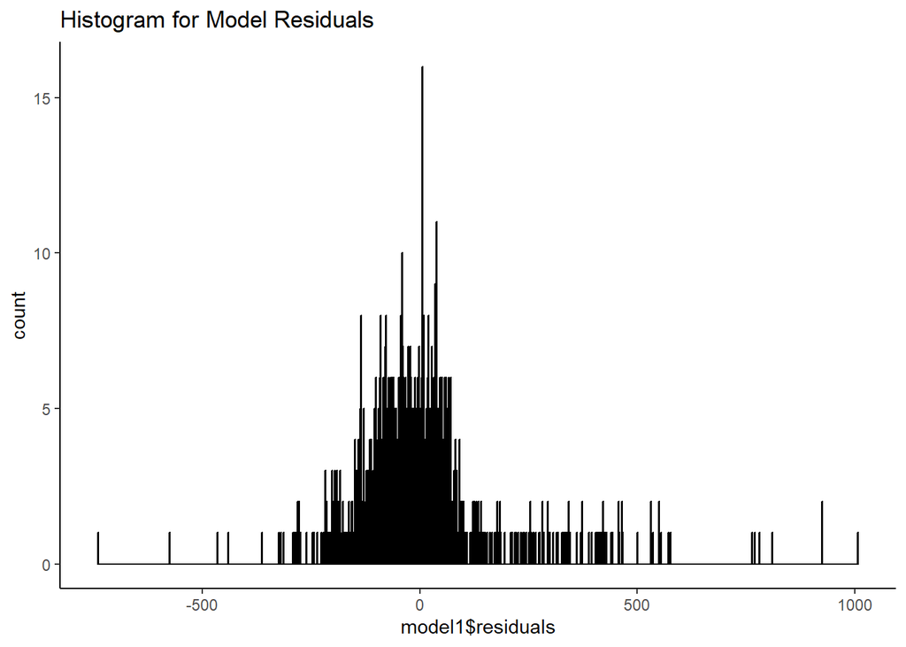

```r
ggplot(data=model1, aes(model1$residuals)) +
geom_histogram(binwidth = 1, color = "black", fill = "purple4") +
theme(panel.background = element_rect(fill = "white"),
axis.line.x=element_line(),
axis.line.y=element_line()) +
ggtitle("Histogram for Model Residuals")
```